# Influence of personal and social benefits on the intention to donate blood in the context of age and the constructs of the Self-Determination Theory - Master Thesis

```r
cor.test(MA_data$ALTER, MA_data$INTRINSIC_REGULATION_SUM)
```

```
##
##  Pearson's product-moment correlation
##
## data:  MA_data$ALTER and MA_data$INTRINSIC_REGULATION_SUM
## t = 8.0128, df = 394, p-value = 1.283e-14
## alternative hypothesis: true correlation is not equal to 0
## 95 percent confidence interval:
##  0.2863475 0.4560536
## sample estimates:
##       cor
## 0.3743307
```

##Table correlation and SDT

```r
subset_cor_SDT <- subset(MA_data, select = c(ALTER,AMOTIVATION_SUM,EXTERNAL_REGULATION_SUM,INTROJECTED_REGULATION_SUM,IDENTIFIED_REGUALTION_SUM,INTEGRATED_REGULATION_SUM,INTRINSIC_REGULATION_SUM))


apa.cor.table(subset_cor_SDT, filename = "Cor_SDT.doc",
              table.number = 85)
```

```
##
##
## Table 85
##
## Means, standard deviations, and correlations with confidence intervals
##
##
##   Variable                      M     SD    1            2
##   1. ALTER                      35.13 12.64
##
##   2. AMOTIVATION_SUM            2.60  1.31  -.23**
##                                             [-.32, -.13]
##
##   3. EXTERNAL_REGULATION_SUM    2.01  1.15  -.18**       .01
##                                             [-.27, -.08] [-.09, .11]
##
##   4. INTROJECTED_REGULATION_SUM 3.95  1.64  -.00         -.34**
##                                             [-.10, .10]  [-.42, -.25]
##
##   5. IDENTIFIED_REGUALTION_SUM  6.28  0.80  .20**        -.46**
##                                             [.10, .29]   [-.54, -.38]
##
##   6. INTEGRATED_REGULATION_SUM  4.87  1.54  .26**        -.55**
##                                             [.17, .35]   [-.61, -.47]
##
##   7. INTRINSIC_REGULATION_SUM   4.51  1.70  .37**        -.53**
##                                             [.29, .46]   [-.60, -.46]
##
##   3           4          5          6
##
##
##
##
##
##
##
##
##   .05
##   [-.05, .15]
##
##   -.05        .53**
##   [-.15, .05] [.45, .59]
##
##   .02         .59**      .66**
##   [-.07, .12] [.52, .65] [.61, .72]
##
##   .06         .50**      .60**      .82**
##   [-.04, .16] [.42, .57] [.53, .66] [.78, .85]
##
##
## Note. M and SD are used to represent mean and standard deviation, respectively.
## Values in square brackets indicate the 95% confidence interval.
## The confidence interval is a plausible range of population correlations
## that could have caused the sample correlation (Cumming, 2014).
##  * indicates p < .05. ** indicates p < .01.
##
```

```r
subset_cor_SDT_INT <- subset(MA_data, select = c(INTENTION_SUM,AMOTIVATION_SUM,EXTERNAL_REGULATION_SUM,INTROJECTED_REGULATION_SUM,IDENTIFIED_REGUALTION_SUM,INTEGRATED_REGULATION_SUM,INTRINSIC_REGULATION_SUM))

apa.cor.table(subset_cor_SDT_INT, filename = "Cor_SDT_INT.doc",
              table.number = 85)
```

```
##
##
## Table 85
##
## Means, standard deviations, and correlations with confidence intervals
##
##
##   Variable                      M    SD   1            2            3
##   1. INTENTION_SUM              5.33 2.22
##
##   2. AMOTIVATION_SUM            2.60 1.31 -.51**
##                                           [-.58, -.43]
##
##   3. EXTERNAL_REGULATION_SUM    2.01 1.15 .05          .01
##                                           [-.04, .15]  [-.09, .11]
##
##   4. INTROJECTED_REGULATION_SUM 3.95 1.64 .37**        -.34**       .05
##                                           [.29, .46]   [-.42, -.25] [-.05, .15]
##
##   5. IDENTIFIED_REGUALTION_SUM  6.28 0.80 .47**        -.46**       -.05
##                                           [.39, .54]   [-.54, -.38] [-.15, .05]
##
##   6. INTEGRATED_REGULATION_SUM  4.87 1.54 .58**        -.55**       .02
##                                           [.52, .65]   [-.61, -.47] [-.07, .12]
##
##   7. INTRINSIC_REGULATION_SUM   4.51 1.70 .61**        -.53**       .06
##                                           [.55, .67]   [-.60, -.46] [-.04, .16]
##
##   4          5          6
##
##
##
##
##
##
##
##
##
##
##
##   .53**
##   [.45, .59]
##
##   .59**      .66**
##   [.52, .65] [.61, .72]
##
##   .50**      .60**      .82**
##   [.42, .57] [.53, .66] [.78, .85]
##
##
## Note. M and SD are used to represent mean and standard deviation, respectively.
## Values in square brackets indicate the 95% confidence interval.
## The confidence interval is a plausible range of population correlations
## that could have caused the sample correlation (Cumming, 2014).
##  * indicates p < .05. ** indicates p < .01.
##
```

##Graphic processing T-Tests

```r
MA_data_tabele_SDT <- MA_data

label(MA_data_tabele_SDT$AMOTIVATION_SUM)       <- "Amotivation"
label(MA_data_tabele_SDT$EXTERNAL_REGULATION_SUM)       <- "Externe Regulation"
label(MA_data_tabele_SDT$INTROJECTED_REGULATION_SUM)     <- "Introjizierte Regulation"
label(MA_data_tabele_SDT$IDENTIFIED_REGUALTION_SUM) <- "Identifizierte Regulation"
label(MA_data_tabele_SDT$INTEGRATED_REGULATION_SUM) <- "Integrierte Regulation"
label(MA_data_tabele_SDT$INTRINSIC_REGULATION_SUM) <- "Intrinsische Motivation"


caption  <- "Deskriptive Daten"
#footnote <- "ᵃ Also known as Breslow thickness"

table1(~ AMOTIVATION_SUM + EXTERNAL_REGULATION_SUM + INTROJECTED_REGULATION_SUM + IDENTIFIED_REGUALTION_SUM + INTEGRATED_REGULATION_SUM + INTRINSIC_REGULATION_SUM | AGE_GROUP, data=MA_data_tabele_SDT, overall=c(left="Total"), caption=caption) #footnote=footnote)
```

Deskriptive Daten

|  | Total (N=396) | 18-29 (N=180) | 30-75 (N=216) |
| --- | --- | --- | --- |
| Amotivation |  |  |  |
| Mean (SD) | 2.60 (1.31) | 2.96 (1.30) | 2.29 (1.25) |
| Median [Min, Max] | 2.33 [1.00, 7.00] | 2.67 [1.00, 6.00] | 2.00 [1.00, 7.00] |
| Externe Regulation |  |  |  |
| Mean (SD) | 2.01 (1.15) | 2.19 (1.18) | 1.85 (1.10) |
| Median [Min, Max] | 1.67 [1.00, 7.00] | 2.00 [1.00, 7.00] | 1.33 [1.00, 7.00] |
| Introjizierte Regulation |  |  |  |
| Mean (SD) | 3.95 (1.64) | 3.84 (1.55) | 4.05 (1.70) |
| Median [Min, Max] | 4.00 [1.00, 7.00] | 4.00 [1.00, 7.00] | 4.00 [1.00, 7.00] |
| Identifizierte Regulation |  |  |  |
| Mean (SD) | 6.28 (0.801) | 6.07 (0.795) | 6.45 (0.766) |
| Median [Min, Max] | 6.33 [2.00, 7.00] | 6.33 [2.00, 7.00] | 6.67 [2.33, 7.00] |
| Integrierte Regulation |  |  |  |
| Mean (SD) | 4.87 (1.54) | 4.32 (1.45) | 5.34 (1.45) |
| Median [Min, Max] | 5.00 [1.00, 7.00] | 4.33 [1.00, 7.00] | 5.67 [1.00, 7.00] |
| Intrinsische Motivation |  |  |  |
| Mean (SD) | 4.51 (1.70) | 3.68 (1.55) | 5.21 (1.49) |
| Median [Min, Max] | 4.67 [1.00, 7.00] | 3.67 [1.00, 7.00] | 5.33 [1.00, 7.00] |

```
## replace the existing one.
## replace the existing one.
```

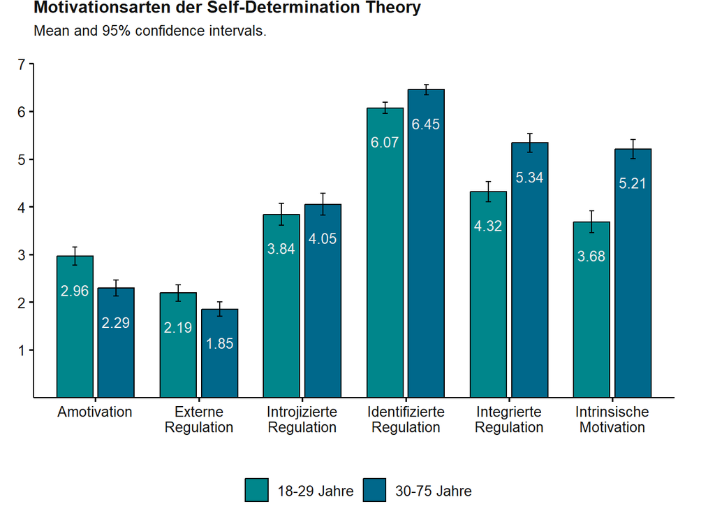

```r
SDTsubset <- MA_data[,c("AMOTIVATION_SUM", "EXTERNAL_REGULATION_SUM", "INTROJECTED_REGULATION_SUM","IDENTIFIED_REGUALTION_SUM", "INTEGRATED_REGULATION_SUM", "INTRINSIC_REGULATION_SUM", "AGE_GROUP")]

data_determinants <- reshape2::melt(SDTsubset,id = "AGE_GROUP")

data_determinants$Determinants <- factor(data_determinants$variable, levels = c("AMOTIVATION_SUM", "EXTERNAL_REGULATION_SUM", "INTROJECTED_REGULATION_SUM","IDENTIFIED_REGUALTION_SUM", "INTEGRATED_REGULATION_SUM", "INTRINSIC_REGULATION_SUM"),
labels = c("Amotivation", "Externe Regulation", "Introjizierte Regulation", "Identifizierte Regulation", "Integrierte Regulation", "Intrinsische Motivation")
)

data_determinants$Determinants <- str_wrap(data_determinants$Determinants, width = 10)
#mean(MA_data$AMOTIVATION_SUM[MA_data$AGE_GROUP == "18-29"])

ggbarplot(
data_determinants,
x = "Determinants",
y = "value",
fill = "AGE_GROUP",
add = c("mean_ci"),
position = position_dodge(0.8),
color = "black",
add.params = list(group = "AGE_GROUP"),
legend = "bottom",
xlab = "",
ylab = "",
ylim = c(0,7),
title = "Motivationsarten der Self-Determination Theory",
subtitle = "Mean and 95% confidence intervals.\n",
font.x = c(10, "plain", "#111111"),
font.y = c(10, "plain", "#111111"),
font.label = c(10, "plain", "#111111"),
font.legend = c(10, "plain", "#111111"),
font.tickslab = c(10, "plain", "#111111"),
font.title = c(12, "bold", "#111111"),
font.subtitle = c(10, "plain", "#111111"),
label = TRUE,
lab.pos = "out",
lab.col = "#eeeeee",
lab.size = 3.6,
lab.vjust = 3.5,
lab.hjust = 0.5,
lab.nb.digits = 2,
orientation = "horiz",
) + scale_fill_manual(
name = "",
labels=c("18-29 Jahre","30-75 Jahre"),
values = c("#00868B","#00688B")
)+ scale_y_continuous(
expand = c(0, 0),
breaks=c(1,2,3,4,5,6,7),
) + coord_cartesian(ylim=c(0,7)) + theme (plot.margin = margin(0, 1, 0, 0, "cm"))
```

#Explorativ

##T-Tests dependent on blood donation behaviour

```r
Only_BDB_Yes <- subset(MA_data, BDB_GROUP == "Ja")

Only_BDB_No <- subset(MA_data, BDB_GROUP == "Nein")
```

##BDB YES

```r
coin::wilcox_test(AMOTIVATION_SUM ~ AGE_GROUP, data = Only_BDB_Yes, alternative = "greater", distribution = "exact", correct = FALSE, conf.int = TRUE, p.adjust.method = "bonferroni")
```

```
##
##  Exact Wilcoxon-Mann-Whitney Test
##
## data:  AMOTIVATION_SUM by AGE_GROUP (18-29, 30-75)
## Z = 3.0722, p-value = 0.001029
## alternative hypothesis: true mu is greater than 0
## 95 percent confidence interval:
##  0.3333333       Inf
## sample estimates:
## difference in location
##              0.3333333
```

```r
wilcox_effsize(Only_BDB_Yes, AMOTIVATION_SUM ~ AGE_GROUP, alternative = "less", mu = 0)
```

```
## # A tibble: 1 × 7
##   .y.             group1 group2 effsize    n1    n2 magnitude
## * <chr>           <chr>  <chr>    <dbl> <int> <int> <ord>
## 1 AMOTIVATION_SUM 18-29  30-75    0.176    97   206 small
```

```r
coin::wilcox_test(EXTERNAL_REGULATION_SUM ~ AGE_GROUP, data = Only_BDB_Yes, alternative = "greater", distribution = "exact", correct = FALSE, conf.int = TRUE, p.adjust.method = "bonferroni")
```

```
##
##  Exact Wilcoxon-Mann-Whitney Test
##
## data:  EXTERNAL_REGULATION_SUM by AGE_GROUP (18-29, 30-75)
## Z = 5.0668, p-value = 1.648e-07
## alternative hypothesis: true mu is greater than 0
## 95 percent confidence interval:
##  0.3333333       Inf
## sample estimates:
## difference in location
##              0.6666667
```

```r
wilcox_effsize(Only_BDB_Yes, EXTERNAL_REGULATION_SUM ~ AGE_GROUP, alternative = "less", mu = 0)
```

```
## # A tibble: 1 × 7
##   .y.                     group1 group2 effsize    n1    n2 magnitude
## * <chr>                   <chr>  <chr>    <dbl> <int> <int> <ord>
## 1 EXTERNAL_REGULATION_SUM 18-29  30-75    0.291    97   206 small
```

```r
coin::wilcox_test(INTROJECTED_REGULATION_SUM ~ AGE_GROUP, data = Only_BDB_Yes, alternative = "less", distribution = "exact", correct = FALSE, conf.int = TRUE, p.adjust.method = "bonferroni")
```

```
##
##  Exact Wilcoxon-Mann-Whitney Test
##
## data:  INTROJECTED_REGULATION_SUM by AGE_GROUP (18-29, 30-75)
## Z = -0.44365, p-value = 0.329
## alternative hypothesis: true mu is less than 0
## 95 percent confidence interval:
##       -Inf 0.3333333
## sample estimates:
## difference in location
##                      0
```

```r
wilcox_effsize(Only_BDB_Yes, INTROJECTED_REGULATION_SUM ~ AGE_GROUP, alternative = "less", mu = 0)
```

```
## # A tibble: 1 × 7
##   .y.                        group1 group2 effsize    n1    n2 magnitude
## * <chr>                      <chr>  <chr>    <dbl> <int> <int> <ord>
## 1 INTROJECTED_REGULATION_SUM 18-29  30-75   0.0255    97   206 small
```

```r
coin::wilcox_test(IDENTIFIED_REGUALTION_SUM ~ AGE_GROUP, data = Only_BDB_Yes, alternative = "less", distribution = "exact", correct = FALSE, conf.int = TRUE, p.adjust.method = "bonferroni")
```

```
##
##  Exact Wilcoxon-Mann-Whitney Test
##
## data:  IDENTIFIED_REGUALTION_SUM by AGE_GROUP (18-29, 30-75)
## Z = -4.0318, p-value = 2.782e-05
## alternative hypothesis: true mu is less than 0
## 95 percent confidence interval:
##  -Inf    0
## sample estimates:
## difference in location
##             -0.3333333
```

```r
wilcox_effsize(Only_BDB_Yes, IDENTIFIED_REGUALTION_SUM ~ AGE_GROUP, alternative = "less", mu = 0)
```

```
## # A tibble: 1 × 7
##   .y.                       group1 group2 effsize    n1    n2 magnitude
## * <chr>                     <chr>  <chr>    <dbl> <int> <int> <ord>
## 1 IDENTIFIED_REGUALTION_SUM 18-29  30-75    0.232    97   206 small
```

```r
coin::wilcox_test(INTEGRATED_REGULATION_SUM ~ AGE_GROUP, data = Only_BDB_Yes, alternative = "less", distribution = "exact", correct = FALSE, conf.int = TRUE, p.adjust.method = "bonferroni")
```

```
##
##  Exact Wilcoxon-Mann-Whitney Test
##
## data:  INTEGRATED_REGULATION_SUM by AGE_GROUP (18-29, 30-75)
## Z = -3.9775, p-value = 3.082e-05
## alternative hypothesis: true mu is less than 0
## 95 percent confidence interval:
##        -Inf -0.3333333
## sample estimates:
## difference in location
##             -0.6666667
```

```r
wilcox_effsize(Only_BDB_Yes, INTEGRATED_REGULATION_SUM ~ AGE_GROUP, alternative = "less", mu = 0)
```

```
## # A tibble: 1 × 7
##   .y.                       group1 group2 effsize    n1    n2 magnitude
## * <chr>                     <chr>  <chr>    <dbl> <int> <int> <ord>
## 1 INTEGRATED_REGULATION_SUM 18-29  30-75    0.228    97   206 small
```

```r
coin::wilcox_test(INTRINSIC_REGULATION_SUM ~ AGE_GROUP, data = Only_BDB_Yes, alternative = "less", distribution = "exact", correct = FALSE, conf.int = TRUE, p.adjust.method = "bonferroni")
```

```
##
##  Exact Wilcoxon-Mann-Whitney Test
##
## data:  INTRINSIC_REGULATION_SUM by AGE_GROUP (18-29, 30-75)
## Z = -5.2048, p-value = 6.425e-08
## alternative hypothesis: true mu is less than 0
## 95 percent confidence interval:
##        -Inf -0.6666667
## sample estimates:
## difference in location
##                     -1
```

```r
wilcox_effsize(Only_BDB_Yes, INTRINSIC_REGULATION_SUM ~ AGE_GROUP, alternative = "less", mu = 0)
```

```
## # A tibble: 1 × 7
##   .y.                      group1 group2 effsize    n1    n2 magnitude
## * <chr>                    <chr>  <chr>    <dbl> <int> <int> <ord>
## 1 INTRINSIC_REGULATION_SUM 18-29  30-75    0.299    97   206 small
```

```
## replace the existing one.
## replace the existing one.
```

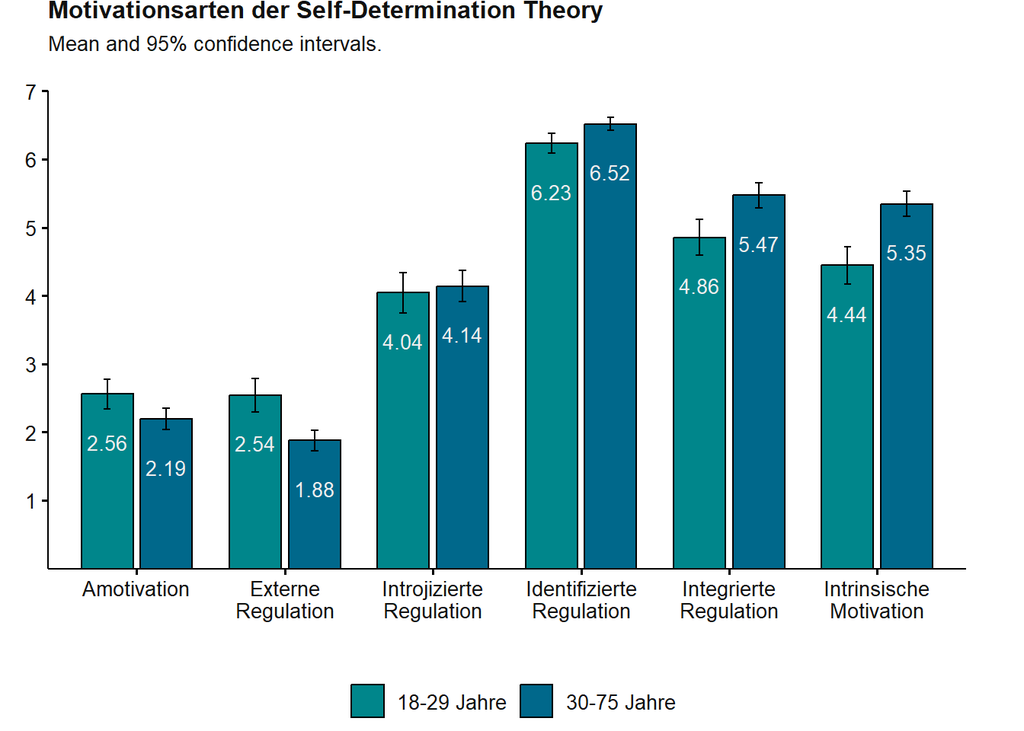

```r
SDTsubset_BDB_YES <- Only_BDB_Yes[,c("AMOTIVATION_SUM", "EXTERNAL_REGULATION_SUM", "INTROJECTED_REGULATION_SUM","IDENTIFIED_REGUALTION_SUM", "INTEGRATED_REGULATION_SUM", "INTRINSIC_REGULATION_SUM", "AGE_GROUP")]

data_determinants_BDB_YES <- reshape2::melt(SDTsubset_BDB_YES,id = "AGE_GROUP")

data_determinants_BDB_YES$Determinants <- factor(data_determinants_BDB_YES$variable, levels = c("AMOTIVATION_SUM", "EXTERNAL_REGULATION_SUM", "INTROJECTED_REGULATION_SUM","IDENTIFIED_REGUALTION_SUM", "INTEGRATED_REGULATION_SUM", "INTRINSIC_REGULATION_SUM"),
labels = c("Amotivation", "Externe Regulation", "Introjizierte Regulation", "Identifizierte Regulation", "Integrierte Regulation", "Intrinsische Motivation")
)

data_determinants_BDB_YES$Determinants <- str_wrap(data_determinants_BDB_YES$Determinants, width = 10)

ggbarplot(
data_determinants_BDB_YES,
x = "Determinants",
y = "value",
fill = "AGE_GROUP",
add = c("mean_ci"),
position = position_dodge(0.8),
color = "black",
add.params = list(group = "AGE_GROUP"),
legend = "bottom",
xlab = "",
ylab = "",
ylim = c(0,7),
title = "Motivationsarten der Self-Determination Theory",
subtitle = "Mean and 95% confidence intervals.\n",
font.x = c(10, "plain", "#111111"),
font.y = c(10, "plain", "#111111"),
font.label = c(10, "plain", "#111111"),
font.legend = c(10, "plain", "#111111"),
font.tickslab = c(10, "plain", "#111111"),
font.title = c(12, "bold", "#111111"),
font.subtitle = c(10, "plain", "#111111"),
label = TRUE,
lab.pos = "out",
lab.col = "#eeeeee",
lab.size = 3.6,
lab.vjust = 3.5,
lab.hjust = 0.5,
lab.nb.digits = 2,
orientation = "horiz",
) + scale_fill_manual(
name = "",
labels=c("18-29 Jahre","30-75 Jahre"),
values = c("#00868B","#00688B")
)+ scale_y_continuous(
expand = c(0, 0),
breaks=c(1,2,3,4,5,6,7),
) + coord_cartesian(ylim=c(0,7)) + theme (plot.margin = margin(0, 1, 0, 0, "cm"))
```

##Cronbachs alpha

```r
MA_data %>%
   group_by(AGE_GROUP) %>%
   summarise(
     M_AMOTIVATION = mean(AMOTIVATION_SUM_1_2, na.rm = TRUE),
     SD_AMOTIVATION = sd(AMOTIVATION_SUM_1_2, na.rm = TRUE),
     M_IDENTIFIED = mean(IDENTIFIED_REGUALTION_SUM_2_3, na.rm = TRUE),
     SD_IDENTIFIED = sd(IDENTIFIED_REGUALTION_SUM_2_3, na.rm = TRUE),
   ) %>%
   as.data.frame()
```

```
##   AGE_GROUP M_AMOTIVATION SD_AMOTIVATION M_IDENTIFIED SD_IDENTIFIED
## 1     18-29      3.008333       1.420594     6.558333     0.7232666
## 2     30-75      2.187500       1.270701     6.701389     0.6231562
```

```r
coin::wilcox_test(MA_data$AMOTIVATION_SUM_1_2 ~ MA_data$AGE_GROUP, data = MA_data, alternative = "greater", distribution = "exact", correct = FALSE, conf.int = TRUE, p.adjust.method = "bonferroni")
```

```
##
##  Exact Wilcoxon-Mann-Whitney Test
##
## data:  MA_data$AMOTIVATION_SUM_1_2 by MA_data$AGE_GROUP (18-29, 30-75)
## Z = 6.3898, p-value = 4.469e-11
## alternative hypothesis: true mu is greater than 0
## 95 percent confidence interval:
##  0.5 Inf
## sample estimates:
## difference in location
##                      1
```

```r
wilcox_effsize(MA_data, AMOTIVATION_SUM_1_2 ~ AGE_GROUP, alternative = "greater", mu = 0)
```

```
## # A tibble: 1 × 7
##   .y.                 group1 group2 effsize    n1    n2 magnitude
## * <chr>               <chr>  <chr>    <dbl> <int> <int> <ord>
## 1 AMOTIVATION_SUM_1_2 18-29  30-75    0.321   180   216 moderate
```

```r
coin::wilcox_test(MA_data$IDENTIFIED_REGUALTION_SUM_2_3 ~ MA_data$AGE_GROUP, data = MA_data, alternative = "less", distribution = "exact", correct = FALSE, conf.int = TRUE)
```

```
##
##  Exact Wilcoxon-Mann-Whitney Test
##
## data:  MA_data$IDENTIFIED_REGUALTION_SUM_2_3 by MA_data$AGE_GROUP (18-29, 30-75)
## Z = -3.2338, p-value = 0.000615
## alternative hypothesis: true mu is less than 0
## 95 percent confidence interval:
##  -Inf    0
## sample estimates:
## difference in location
##                      0
```

```r
wilcox_effsize(MA_data, IDENTIFIED_REGUALTION_SUM_2_3 ~ AGE_GROUP, alternative = "less", mu = 0)
```

```
## # A tibble: 1 × 7
##   .y.                           group1 group2 effsize    n1    n2 magnitude
## * <chr>                         <chr>  <chr>    <dbl> <int> <int> <ord>
## 1 IDENTIFIED_REGUALTION_SUM_2_3 18-29  30-75    0.163   180   216 small
```

```
## replace the existing one.
## replace the existing one.
```

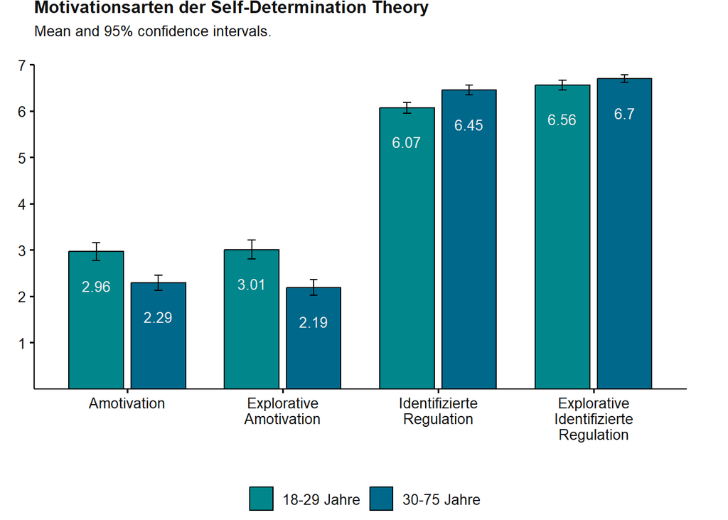

```r
SDTsubset_exp <- MA_data[,c("AMOTIVATION_SUM", "AMOTIVATION_SUM_1_2", "IDENTIFIED_REGUALTION_SUM", "IDENTIFIED_REGUALTION_SUM_2_3", "AGE_GROUP")]

data_determinants_exp <- reshape2::melt(SDTsubset_exp,id = "AGE_GROUP")

data_determinants_exp$Determinants <- factor(data_determinants_exp$variable, levels = c("AMOTIVATION_SUM", "AMOTIVATION_SUM_1_2", "IDENTIFIED_REGUALTION_SUM", "IDENTIFIED_REGUALTION_SUM_2_3"),
labels = c("Amotivation", "Explorative Amotivation", "Identifizierte Regulation", "Explorative Identifizierte Regulation")
)

data_determinants_exp$Determinants <- str_wrap(data_determinants_exp$Determinants, width = 10)

ggbarplot(
data_determinants_exp,
x = "Determinants",
y = "value",
fill = "AGE_GROUP",
add = c("mean_ci"),
position = position_dodge(0.8),
color = "black",
add.params = list(group = "AGE_GROUP"),
legend = "bottom",
xlab = "",
ylab = "",
ylim = c(0,7),
title = "Motivationsarten der Self-Determination Theory",
subtitle = "Mean and 95% confidence intervals.\n",
font.x = c(10, "plain", "#111111"),
font.y = c(10, "plain", "#111111"),
font.label = c(10, "plain", "#111111"),
font.legend = c(10, "plain", "#111111"),
font.tickslab = c(10, "plain", "#111111"),
font.title = c(12, "bold", "#111111"),
font.subtitle = c(10, "plain", "#111111"),
label = TRUE,
lab.pos = "out",
lab.col = "#eeeeee",
lab.size = 3.6,
lab.vjust = 3.5,
lab.hjust = 0.5,
lab.nb.digits = 2,
orientation = "horiz",
) + scale_fill_manual(
name = "",
labels=c("18-29 Jahre","30-75 Jahre"),
values = c("#00868B","#00688B")
)+ scale_y_continuous(
expand = c(0, 0),
breaks=c(1,2,3,4,5,6,7),
) + coord_cartesian(ylim=c(0,7)) + theme (plot.margin = margin(0, 1, 0, 0, "cm"))
```

##Prerequisite tests for moderated mediation

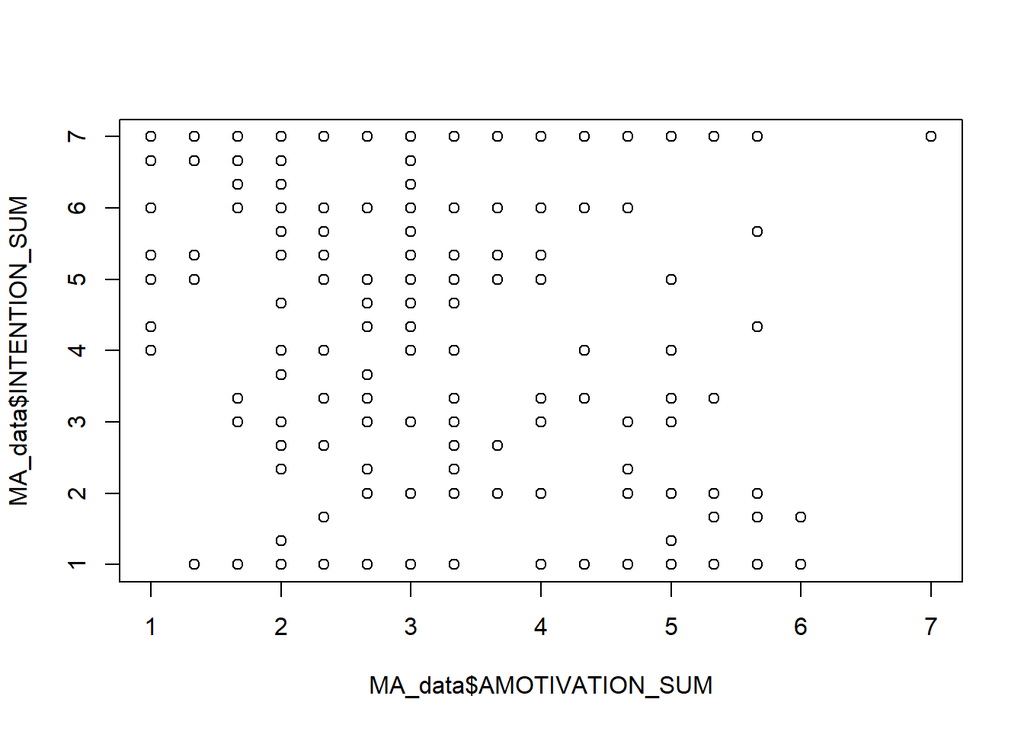

```r
plot(MA_data$AMOTIVATION_SUM,MA_data$INTENTION_SUM)
```

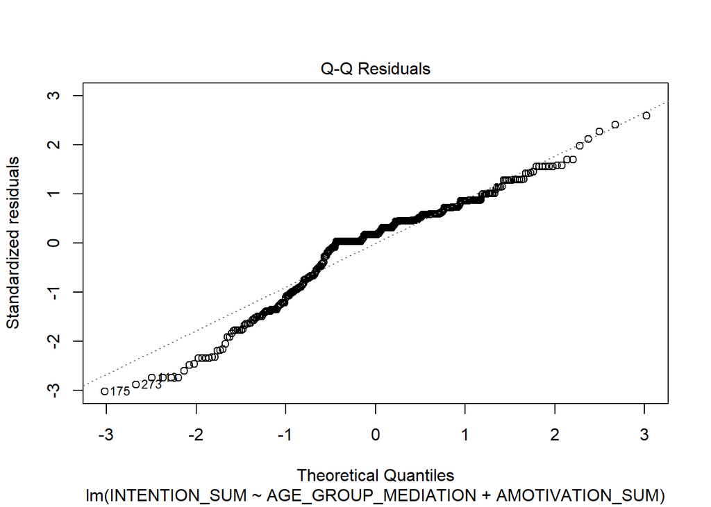

```r
M_Amotivation <- lm(INTENTION_SUM ~ AGE_GROUP_MEDIATION + AMOTIVATION_SUM ,  data = MA_data)
plot(M_Amotivation, 2)
```

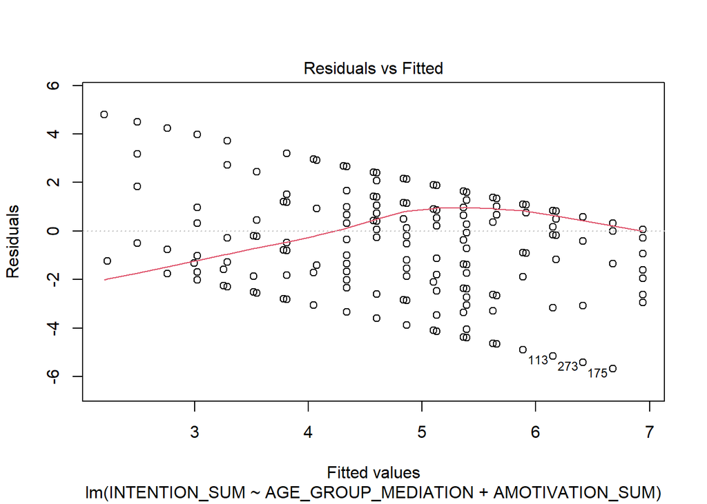

```r
plot(M_Amotivation, 1)
```

```r
vif(M_Amotivation)
```

```
## AGE_GROUP_MEDIATION     AMOTIVATION_SUM
##            1.069745            1.069745
```

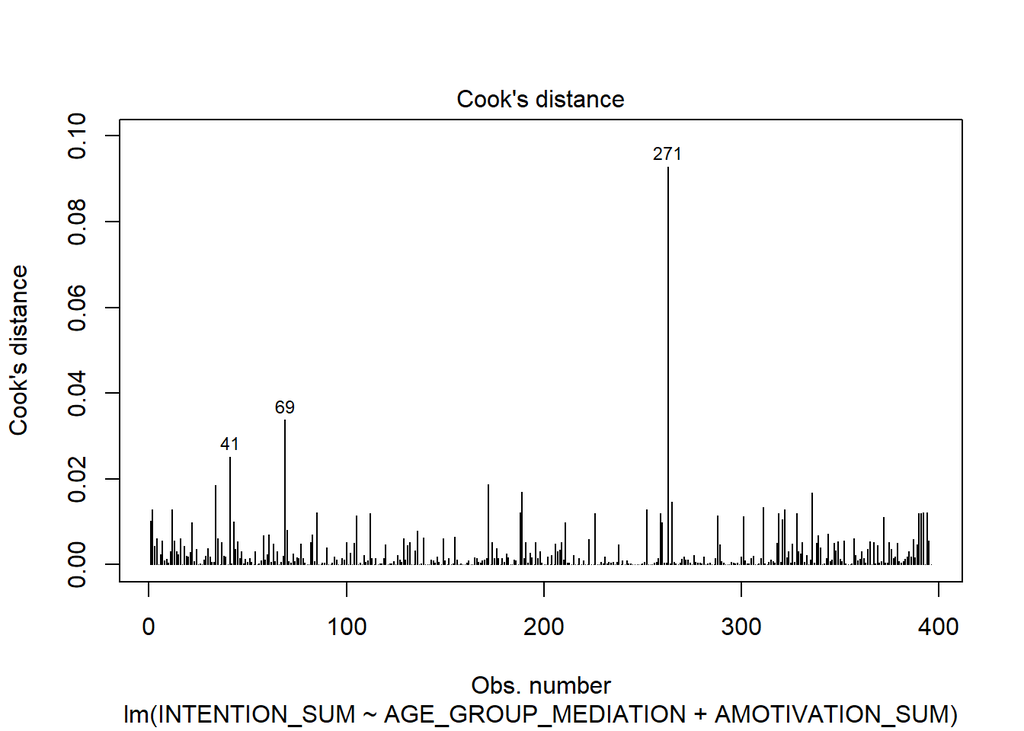

```r
#VIF < 10 alright
plot(M_Amotivation, 4)
```

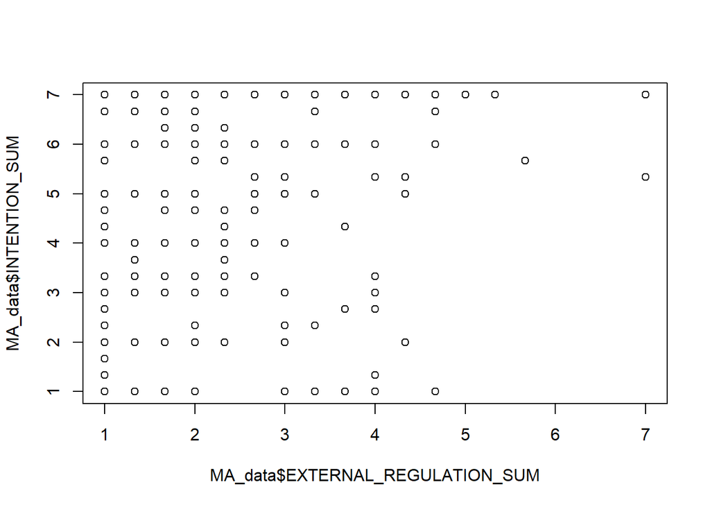

```r
plot(MA_data$EXTERNAL_REGULATION_SUM,MA_data$INTENTION_SUM)
```

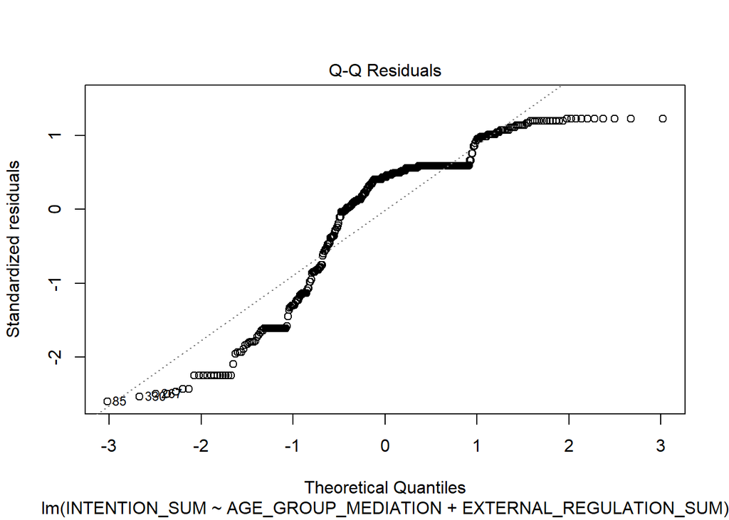

```r
M_EXTERNAL_REGULATION_SUM <- lm(INTENTION_SUM ~ AGE_GROUP_MEDIATION + EXTERNAL_REGULATION_SUM ,  data = MA_data)
plot(M_EXTERNAL_REGULATION_SUM, 2)
```

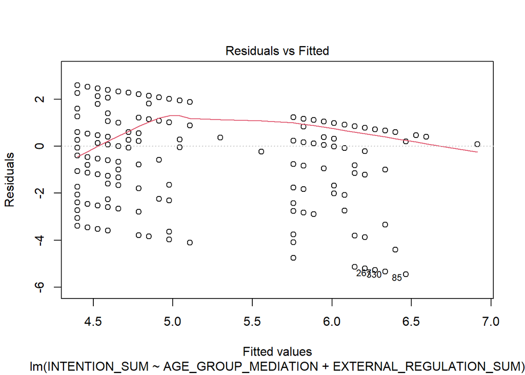

```r
plot(M_EXTERNAL_REGULATION_SUM, 1)
```

```r
vif(M_EXTERNAL_REGULATION_SUM)
```

```
##     AGE_GROUP_MEDIATION EXTERNAL_REGULATION_SUM
##                1.022307                1.022307
```

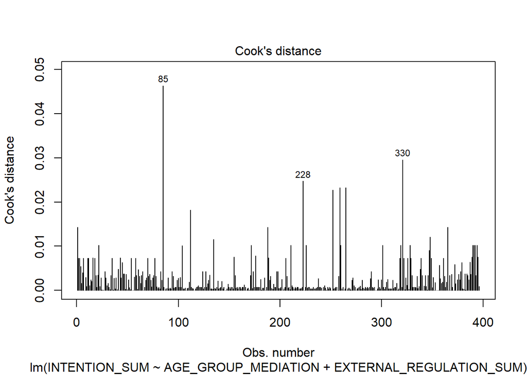

```r
#VIF < 10 alright
plot(M_EXTERNAL_REGULATION_SUM, 4)
```

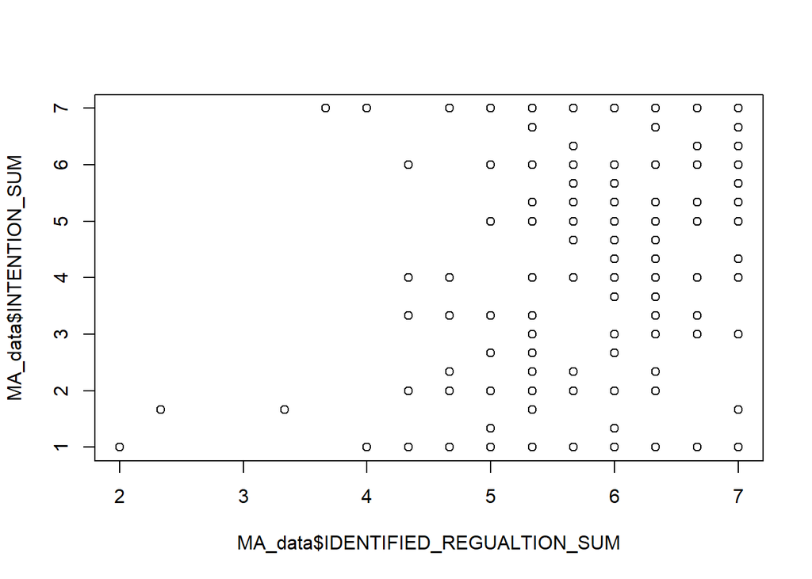

```r
plot(MA_data$IDENTIFIED_REGUALTION_SUM,MA_data$INTENTION_SUM)
```

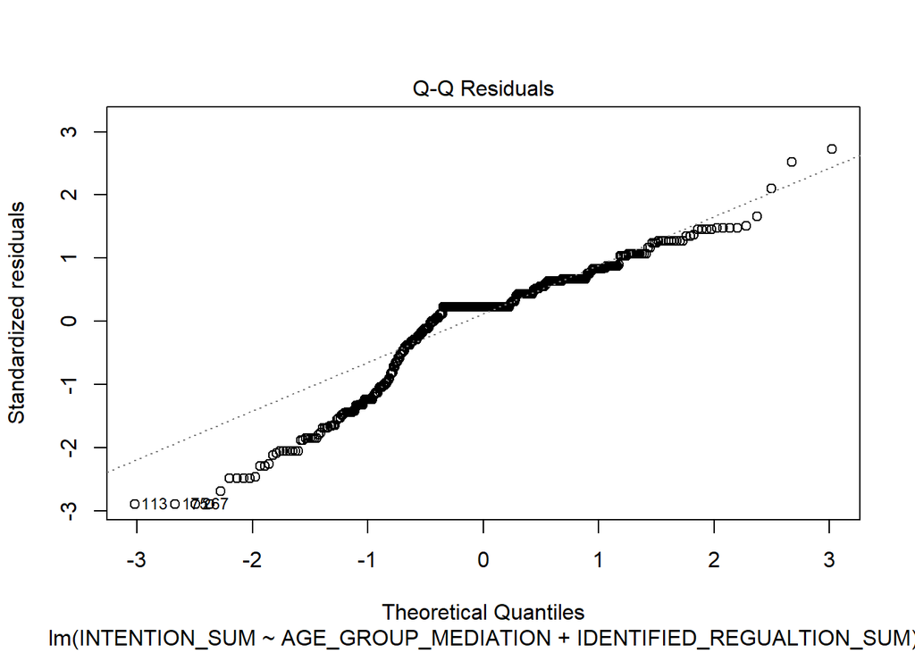

```r
M_IDENTIFIED_REGUALTION_SUM <- lm(INTENTION_SUM ~ AGE_GROUP_MEDIATION + IDENTIFIED_REGUALTION_SUM ,  data = MA_data)
plot(M_IDENTIFIED_REGUALTION_SUM, 2)
```

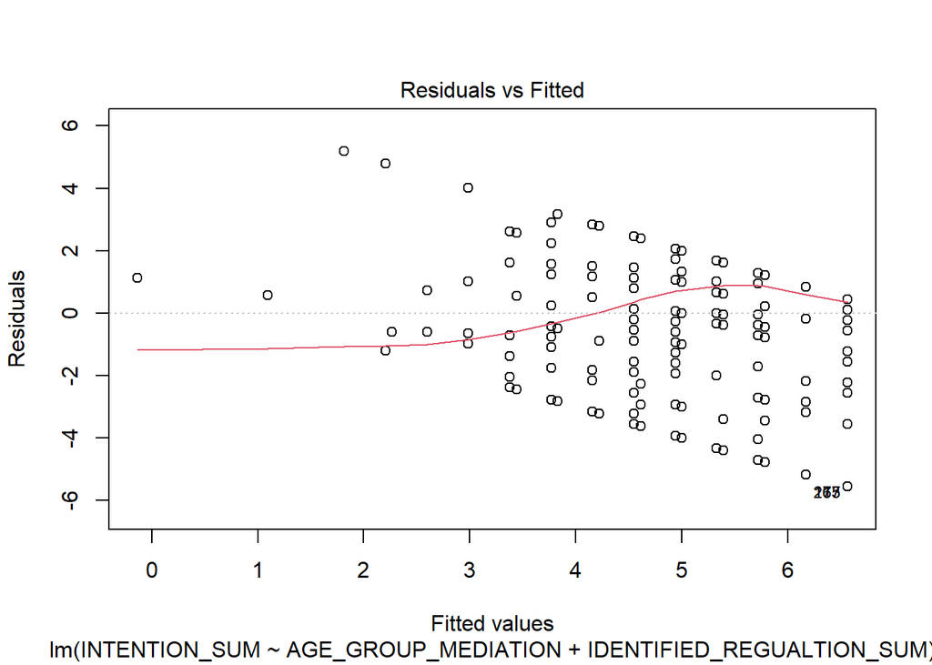

```r
plot(M_IDENTIFIED_REGUALTION_SUM, 1)
```

```r
vif(M_IDENTIFIED_REGUALTION_SUM)
```

```
##       AGE_GROUP_MEDIATION IDENTIFIED_REGUALTION_SUM
##                  1.060286                  1.060286
```

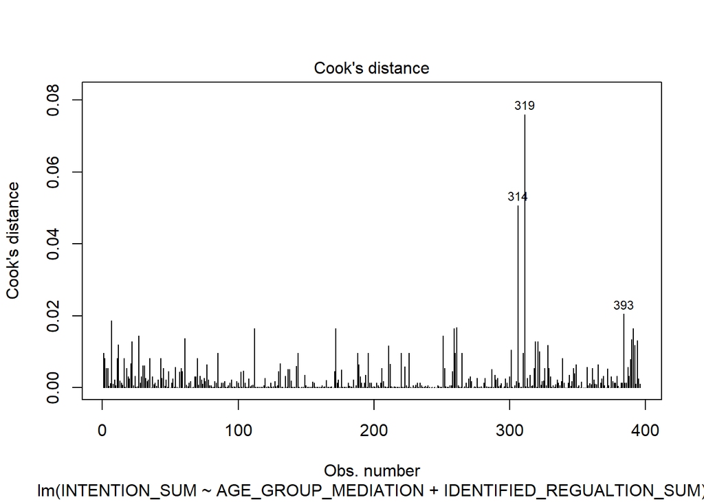

```r
#VIF < 10 alright
plot(M_IDENTIFIED_REGUALTION_SUM, 4)
```

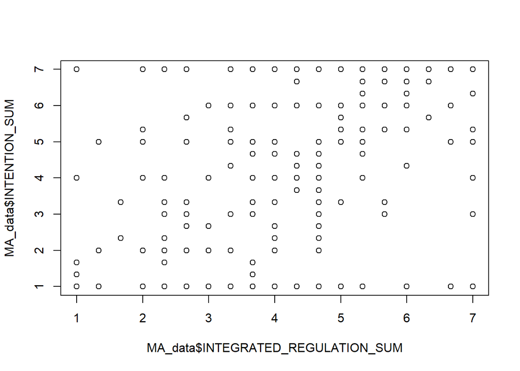

```r
plot(MA_data$INTEGRATED_REGULATION_SUM,MA_data$INTENTION_SUM)
```

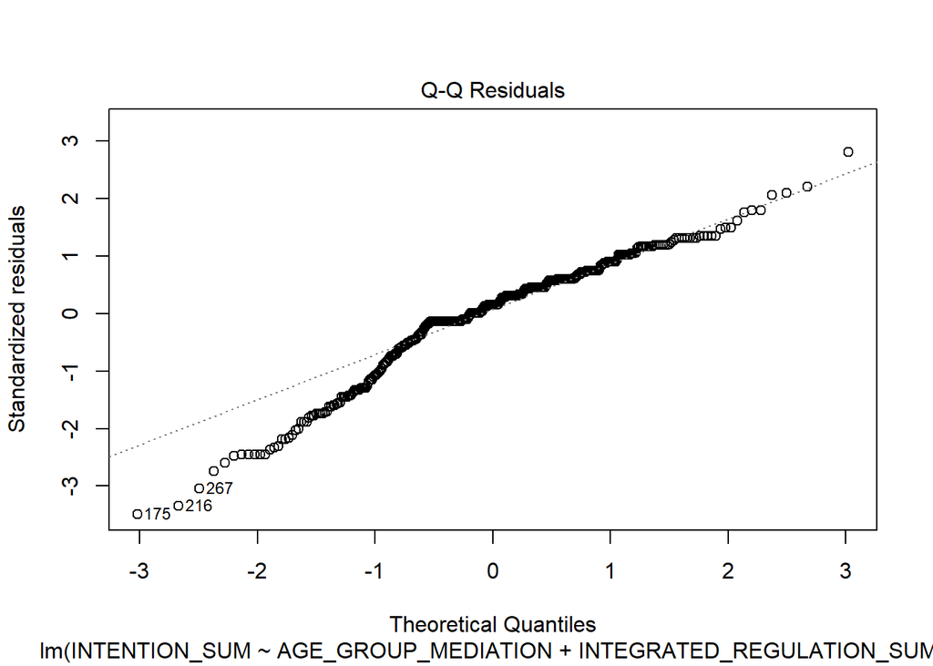

```r
M_INTEGRATED_REGULATION_SUM <- lm(INTENTION_SUM ~ AGE_GROUP_MEDIATION + INTEGRATED_REGULATION_SUM ,  data = MA_data)
plot(M_INTEGRATED_REGULATION_SUM, 2)
```

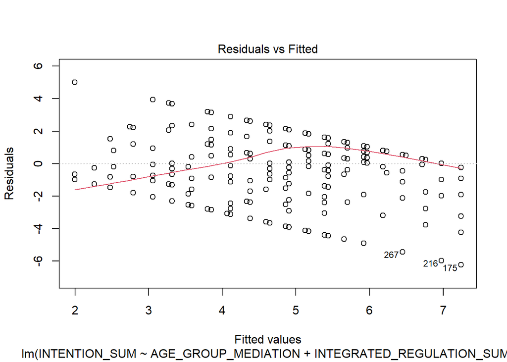

```r
plot(M_INTEGRATED_REGULATION_SUM, 1)
```

```r
vif(M_INTEGRATED_REGULATION_SUM)
```

```
##       AGE_GROUP_MEDIATION INTEGRATED_REGULATION_SUM
##                  1.123101                  1.123101
```

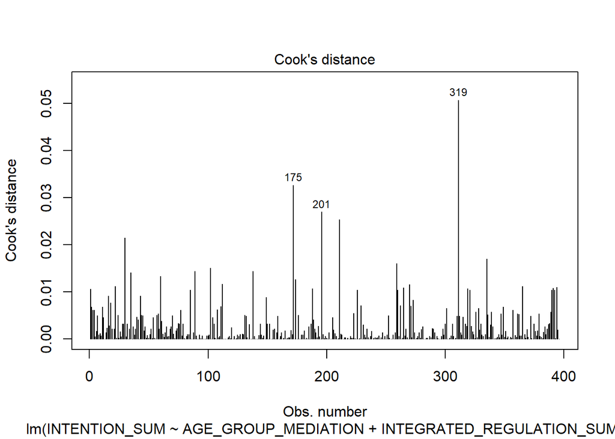

```r
#VIF < 10 alright
plot(M_INTEGRATED_REGULATION_SUM, 4)
```

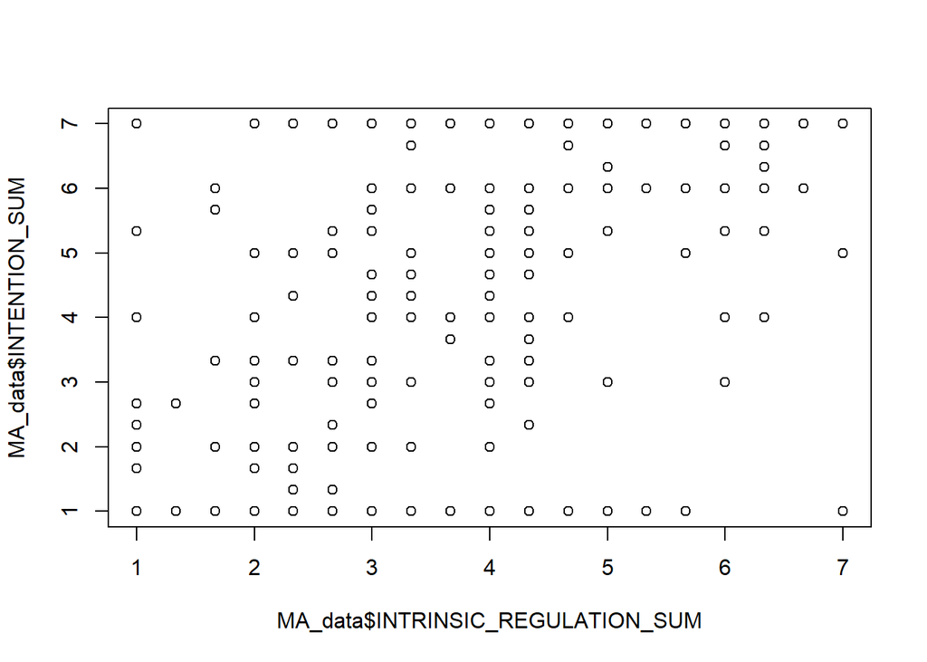

```r
plot(MA_data$INTRINSIC_REGULATION_SUM,MA_data$INTENTION_SUM)
```

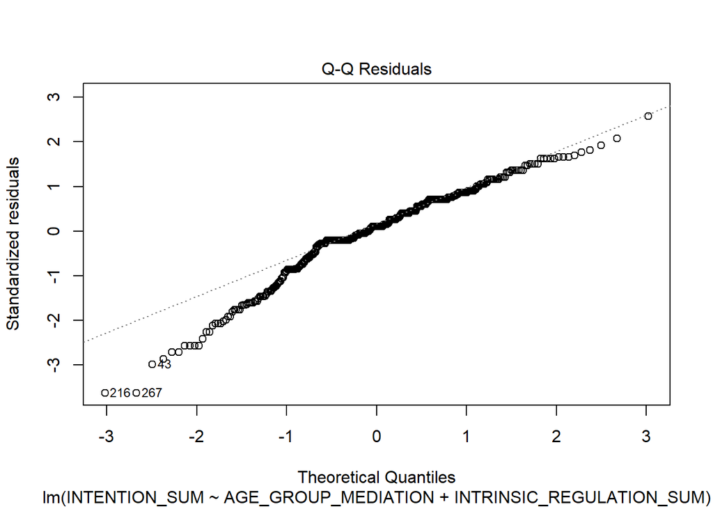

```r
M_INTRINSIC_REGULATION_SUM <- lm(INTENTION_SUM ~ AGE_GROUP_MEDIATION + INTRINSIC_REGULATION_SUM ,  data = MA_data)
plot(M_INTRINSIC_REGULATION_SUM, 2)
```

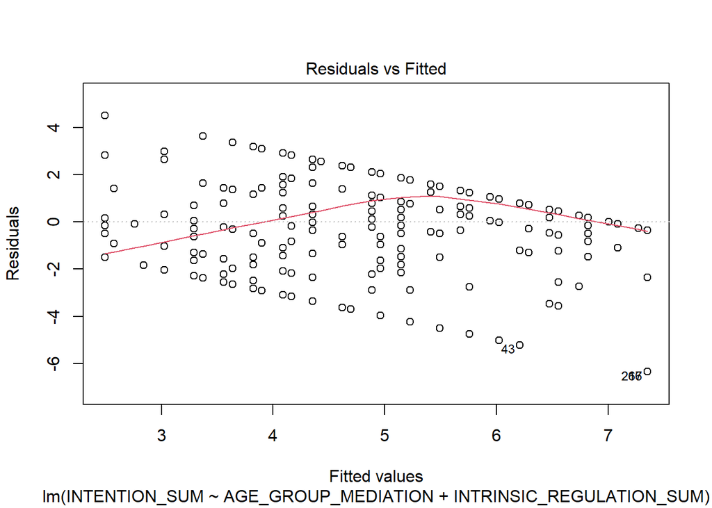

```r
plot(M_INTRINSIC_REGULATION_SUM, 1)
```

```r
vif(M_INTRINSIC_REGULATION_SUM)
```

```
##      AGE_GROUP_MEDIATION INTRINSIC_REGULATION_SUM
##                  1.25104                  1.25104
```

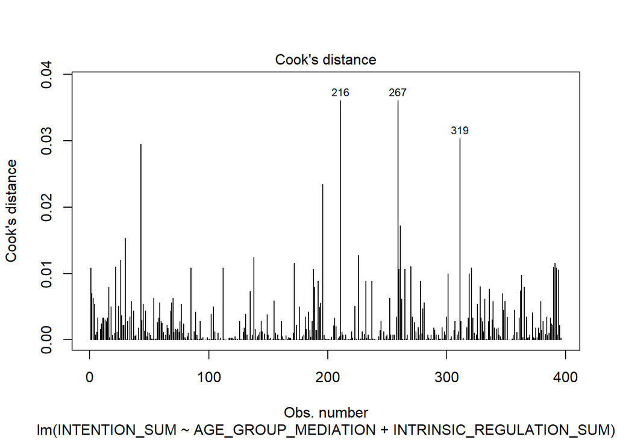

```r
#VIF < 10 alright
plot(M_INTRINSIC_REGULATION_SUM, 4)
```

##Moderated mediation ##The PROCESS from Hayes can be downloaded here: https://www.processmacro.org/download.html The moderated mediations can only be calculated after successful execution.

process(data = MA_data, model=15, x= “AGE_GROUP_MEDIATION”, y=“INTENTION_SUM”, m=“AMOTIVATION_SUM”, w=“c_0001”,seed = 654321)

process(data = MA_data, model=15, x= “AGE_GROUP_MEDIATION”, y=“INTENTION_SUM”, m=“EXTERNAL_REGULATION_SUM”, w=“c_0001”,seed = 654321)

process(data = MA_data, model=15, x= “AGE_GROUP_MEDIATION”, y=“INTENTION_SUM”, m=“IDENTIFIED_REGUALTION_SUM”, w=“c_0001”,seed = 654321)

process(data = MA_data, model=15, x= “AGE_GROUP_MEDIATION”, y=“INTENTION_SUM”, m=“INTEGRATED_REGULATION_SUM”, w=“c_0001”,seed = 654321)

process(data = MA_data, model=15, x= “AGE_GROUP_MEDIATION”, y=“INTENTION_SUM”, m=“INTRINSIC_REGULATION_SUM”, w=“c_0001”,seed = 654321)

##Correlations

```r
cor.test(MA_data$INTENTION_SUM, MA_data$AMOTIVATION_SUM)
```

```
##
##  Pearson's product-moment correlation
##
## data:  MA_data$INTENTION_SUM and MA_data$AMOTIVATION_SUM
## t = -11.745, df = 394, p-value < 2.2e-16
## alternative hypothesis: true correlation is not equal to 0
## 95 percent confidence interval:
##  -0.5787498 -0.4324014
## sample estimates:
##        cor
## -0.5092478
```

```r
cor.test(MA_data$INTENTION_SUM, MA_data$EXTERNAL_REGULATION_SUM)
```

```
##
##  Pearson's product-moment correlation
##
## data:  MA_data$INTENTION_SUM and MA_data$EXTERNAL_REGULATION_SUM
## t = 1.0891, df = 394, p-value = 0.2768
## alternative hypothesis: true correlation is not equal to 0
## 95 percent confidence interval:
##  -0.04399962  0.15250703
## sample estimates:
##        cor
## 0.05478415
```

```r
cor.test(MA_data$INTENTION_SUM, MA_data$INTROJECTED_REGULATION_SUM)
```

```
##
##  Pearson's product-moment correlation
##
## data:  MA_data$INTENTION_SUM and MA_data$INTROJECTED_REGULATION_SUM
## t = 7.998, df = 394, p-value = 1.422e-14
## alternative hypothesis: true correlation is not equal to 0
## 95 percent confidence interval:
##  0.2857134 0.4555065
## sample estimates:
##       cor
## 0.3737367
```

```r
cor.test(MA_data$INTENTION_SUM, MA_data$IDENTIFIED_REGUALTION_SUM)
```

```
##
##  Pearson's product-moment correlation
##
## data:  MA_data$INTENTION_SUM and MA_data$IDENTIFIED_REGUALTION_SUM
## t = 10.487, df = 394, p-value < 2.2e-16
## alternative hypothesis: true correlation is not equal to 0
## 95 percent confidence interval:
##  0.3863612 0.5407747
## sample estimates:
##      cor
## 0.467122
```

```r
cor.test(MA_data$INTENTION_SUM, MA_data$INTEGRATED_REGULATION_SUM)
```

```
##
##  Pearson's product-moment correlation
##
## data:  MA_data$INTENTION_SUM and MA_data$INTEGRATED_REGULATION_SUM
## t = 14.296, df = 394, p-value < 2.2e-16
## alternative hypothesis: true correlation is not equal to 0
## 95 percent confidence interval:
##  0.5155585 0.6457682
## sample estimates:
##       cor
## 0.5844128
```

```r
cor.test(MA_data$INTENTION_SUM, MA_data$INTRINSIC_REGULATION_SUM)
```

```
##
##  Pearson's product-moment correlation
##
## data:  MA_data$INTENTION_SUM and MA_data$INTRINSIC_REGULATION_SUM
## t = 15.471, df = 394, p-value < 2.2e-16
## alternative hypothesis: true correlation is not equal to 0
## 95 percent confidence interval:
##  0.5494820 0.6725437
## sample estimates:
##       cor
## 0.6147404
```